# Portland CSO Data ANalysis 2015-2017

# Load Libraries

```r
#library(readxl)
library(readr)
library(tidyverse)
```

# Assemble data

```r
wide.data <- read_csv("Portland CSO Activity 2015-2017.csv",
        col_types = cols(enddate = col_date(format = "%m/%d/%Y"),
                         eventno = col_character(),
                         startdate = col_date(format = "%m/%d/%Y")))
wide.data$TOTAL <- rowSums(wide.data[,5:35], na.rm = TRUE)
wide.data$COUNT <- rowSums(wide.data[,5:35]>0, na.rm = TRUE)
wide.data$YEAR <- factor(format(wide.data$startdate, "%Y"))
summary(wide.data[,1:5])
```

```
     number        eventno            startdate             enddate               CSO002
 Min.   : 0.00   Length:112         Min.   :2015-01-18   Min.   :2007-04-22   Min.   :   0.00
 1st Qu.: 9.75   Class :character   1st Qu.:2015-10-06   1st Qu.:2015-09-26   1st Qu.:   0.00
 Median :19.00   Mode  :character   Median :2016-08-14   Median :2016-08-03   Median :   0.00
 Mean   :18.87                      Mean   :2016-07-27   Mean   :2016-06-25   Mean   :  52.63
 3rd Qu.:28.00                      3rd Qu.:2017-05-02   3rd Qu.:2017-05-03   3rd Qu.:   0.00
 Max.   :39.00                      Max.   :2017-12-12   Max.   :2017-12-12   Max.   :4000.00
                                                                              NA's   :36
```

```r
summary(wide.data[,30:40])
```

```
     CSO030           CSO032           CSO033             CSO039            CSO042            CSO043     totprecip        maxprecip
 Min.   :     0   Min.   :     0   Min.   :       0   Min.   :      0   Min.   :      0   Min.   :0    Min.   :0.1300   Min.   :0.050
 1st Qu.:     0   1st Qu.:     0   1st Qu.:       0   1st Qu.:    750   1st Qu.:      0   1st Qu.:0    1st Qu.:0.3675   1st Qu.:0.130
 Median :     0   Median :     0   Median :       0   Median :  29500   Median :      0   Median :0    Median :0.6250   Median :0.210
 Mean   :  5232   Mean   :  4343   Mean   :  193186   Mean   : 159087   Mean   :  87063   Mean   :0    Mean   :0.9523   Mean   :0.279
 3rd Qu.:     0   3rd Qu.:     0   3rd Qu.:       0   3rd Qu.: 164000   3rd Qu.:  63500   3rd Qu.:0    3rd Qu.:1.1275   3rd Qu.:0.320
 Max.   :487000   Max.   :237000   Max.   :12537000   Max.   :2063000   Max.   :1571000   Max.   :0    Max.   :5.7300   Max.   :2.050
                                                                                          NA's   :39
     TOTAL              COUNT         YEAR
 Min.   :    2000   Min.   : 1.00   2015:35
 1st Qu.:  410750   1st Qu.: 4.75   2016:38
 Median : 1585150   Median :10.50   2017:39
 Mean   : 6289487   Mean   :10.29
 3rd Qu.: 6041500   3rd Qu.:15.00
 Max.   :76692000   Max.   :24.00
```

# Rearrange data to provide a “Tall” version

```r
tmp <- wide.data %>% select(-number, -TOTAL, -COUNT)
tall.data <- gather(tmp, CSO, Discharge, CSO002:CSO042)
tall.data$CSO <- factor(tall.data$CSO)
rm(tmp)
summary(tall.data)
```

```
   eventno            startdate             enddate               CSO043       totprecip        maxprecip       YEAR           CSO
 Length:3360        Min.   :2015-01-18   Min.   :2007-04-22   Min.   :0      Min.   :0.1300   Min.   :0.050   2015:1050   CSO002 : 112
 Class :character   1st Qu.:2015-10-06   1st Qu.:2015-09-26   1st Qu.:0      1st Qu.:0.3675   1st Qu.:0.130   2016:1140   CSO004 : 112
 Mode  :character   Median :2016-08-14   Median :2016-08-03   Median :0      Median :0.6250   Median :0.210   2017:1170   CSO005 : 112
                    Mean   :2016-07-27   Mean   :2016-06-25   Mean   :0      Mean   :0.9523   Mean   :0.279               CSO006 : 112
                    3rd Qu.:2017-05-02   3rd Qu.:2017-05-03   3rd Qu.:0      3rd Qu.:1.1275   3rd Qu.:0.320               CSO007 : 112
                    Max.   :2017-12-12   Max.   :2017-12-12   Max.   :0      Max.   :5.7300   Max.   :2.050               CSO008 : 112
                                                              NA's   :1170                                                (Other):2688
   Discharge
 Min.   :       0
 1st Qu.:       0
 Median :       0
 Mean   :  221099
 3rd Qu.:   46750
 Max.   :32491000
 NA's   :174
```

# Total Discharges

What are our total discharge volumes each year, in MIllions of Gallons?

```r
tapply(tall.data$Discharge, tall.data$YEAR, sum, na.rm = TRUE)/1000000
```

```
    2015     2016     2017
221.0859 318.3597 164.9770
```

Compare that to the Total Portland EEWTF Overflow

Year Total CSO Overflow EEWTF Overflow 2015 221085900 165,380,000 2016 318,359,690 178,190,000 2017 164,977,000 211,460,000

And nominal DAILY discharge of ~ 18 MGD x 365 days….

# Summarize Discharges by CSO

```r
csosumsandcounts <- tall.data %>% group_by(YEAR,CSO) %>% summarize(discharge = sum(Discharge, na.rm = TRUE), events = sum(Discharge>0, na.rm = TRUE))
CSO_Summary <- csosumsandcounts %>% group_by(CSO) %>% summarize(means = mean(discharge, na.rm=TRUE), sds = sd(discharge, na.rm = TRUE),
                                                       meancount = mean(events, na.rm=TRUE), sdcount = sd(events, na.rm = TRUE))
write.table(CSO_Summary, 'CSO_OutfallCharacteristics.csv', sep = ',')
```

## Which CSOs have not discharged in last three years?

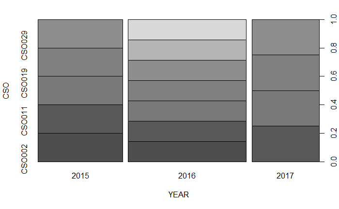

```r
tmp <- csosumsandcounts[which(csosumsandcounts$events==0),c(1,2)]
plot(tmp)
```

```r
CSO_Summary$CSO[which(CSO_Summary$meancount<=3)]
```

```
[1] CSO002 CSO004 CSO008 CSO009 CSO011 CSO019 CSO030
30 Levels: CSO002 CSO004 CSO005 CSO006 CSO007 CSO008 CSO009 CSO010 CSO011 CSO012 CSO013 CSO014 CSO015 CSO016 CSO017 CSO018 ... CSO042
```

## Which CSOs have not discharged in EACH of the last three years?

```r
tall.data$CSO[which(CSO_Summary$means==0)]
```

[output not shown]

## Plot a histogram showing the distibution of discharges

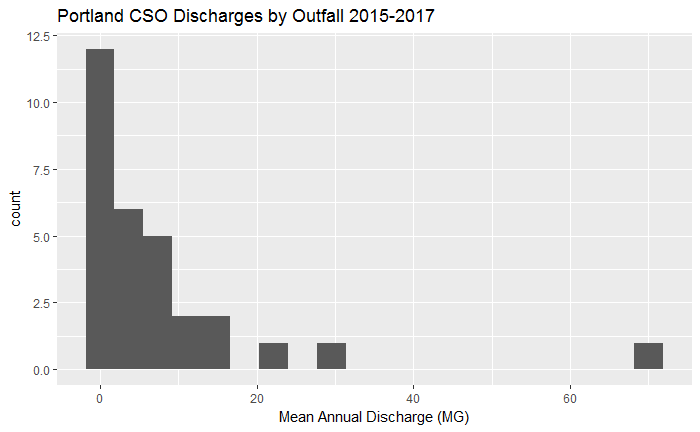

```r
plt <- ggplot(CSO_Summary) + aes(means/1000000) + geom_histogram(bins = 20) + xlab("Mean Annual Discharge (MG)") + ggtitle('Portland CSO Discharges by Outfall 2015-2017')
plt
```

## Try to fit a gGAMMA distribution. Not very satisfactory….

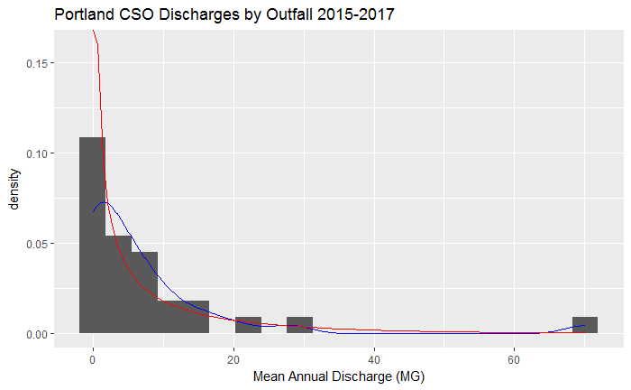

```r
plt <- ggplot(CSO_Summary) + aes(means/1000000) + geom_histogram(aes(y=..density..), bins = 20) + xlab("Mean Annual Discharge (MG)") + ggtitle('Portland CSO Discharges by Outfall 2015-2017')
plt <- plt + stat_density(colour="blue", geom="line", position="identity") +
  #stat_function(fun=dnorm, args=list(mean=mean(CSO_Summary$means/1000000), sd=sd(CSO_Summary$means/1000000))) +
  stat_function(fun=dgamma, args=list(shape=mean(CSO_Summary$means/1000000)^2/sd(CSO_Summary$means/1000000)^2, scale=sd(CSO_Summary$means/1000000)^2/mean(CSO_Summary$means/1000000)), color = 'red')
plt
```

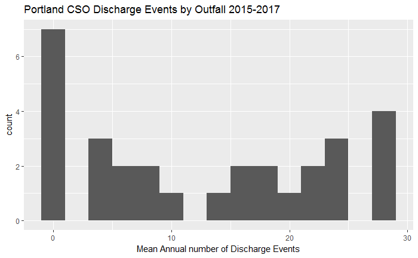

```r
plt <- ggplot(CSO_Summary) + aes(meancount) + geom_histogram(binwidth = 2) + xlab("Mean Annual number of Discharge Events") + ggtitle('Portland CSO Discharge Events by Outfall 2015-2017')
plt
```

## Plot the relationship betwen TOTAL discharges and the NUMBER Of discharges for each Outfall

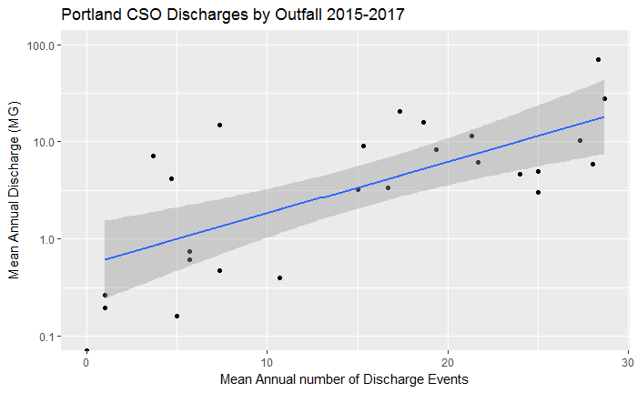

```r
plt <- ggplot(CSO_Summary) + aes(meancount, means/1000000) + geom_point() + geom_smooth(method = 'lm')
plt <- plt + xlab("Mean Annual number of Discharge Events")  + ylab("Mean Annual Discharge (MG)") + ggtitle('Portland CSO Discharges by Outfall 2015-2017')
plt <- plt + scale_y_log10(limits = c(0.1,100), breaks = c(0.1,1,10, 100))
plt
```

## Plot discharge behavior for each outfall

```r
plt <- ggplot(csosumsandcounts) + aes(discharge/1000000, CSO, color = YEAR) + geom_point() + xlab("Total Annual Discharge (MG)") + ggtitle('Portland CSO Discharges 2015-2017') + scale_x_log10(limits = c(0.1,100), breaks = c(0.1,1,10, 100))
plt
```

[output not shown]

```r
plt <- ggplot(csosumsandcounts) + aes(events, CSO, color = YEAR) + geom_point() + xlab("Number of Discharge Events") + ggtitle('Portland CSO Discharges 2015-2017')
plt
```

[output not shown]

## Relationship betwwen annual discharge and annual number of discharge events accross all outfalls and years.

```r
plt <- ggplot(csosumsandcounts) + geom_point(aes(discharge/1000000, events, shape = YEAR , color= CSO)) + geom_smooth(aes(discharge/1000000, events), method = 'lm')
plt <- plt + xlab("Total Annual Discharge (MG)") + ylab('Number of Discharge Events') + ggtitle('Portland CSO Discharges 2015-2017')
plt <- plt + scale_x_log10() + scale_y_log10()
plt
```

[output not shown]

# Looking for patterns in relationship to rainfall

## Annual rainfall Patterns

Note a large storm in 2015.

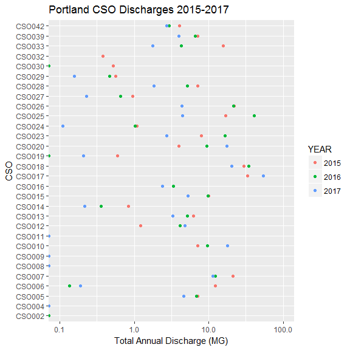

```r
plt <- ggplot(csosumsandcounts) + aes(discharge/1000000, CSO, color = YEAR) + geom_point() + xlab("Total Annual Discharge (MG)") + ggtitle('Portland CSO Discharges 2015-2017') + scale_x_log10(limits = c(0.1,100), breaks = c(0.1,1,10, 100))
plt
```

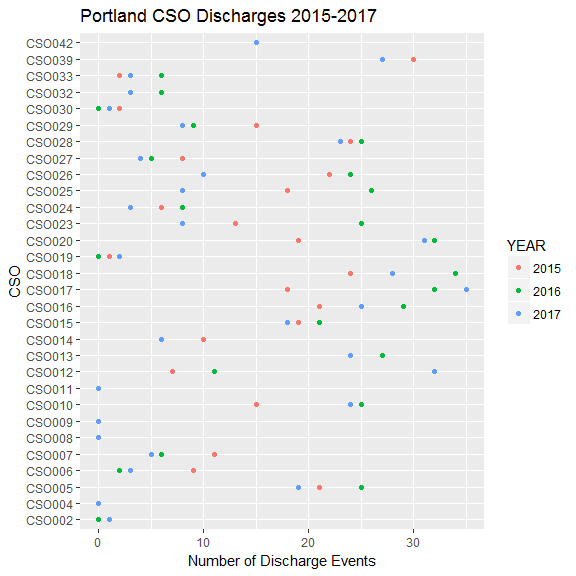

```r
plt <- ggplot(csosumsandcounts) + aes(events, CSO, color = YEAR) + geom_point() + xlab("Number of Discharge Events") + ggtitle('Portland CSO Discharges 2015-2017')
plt
```

## Seasonal Rainfall Patterns?

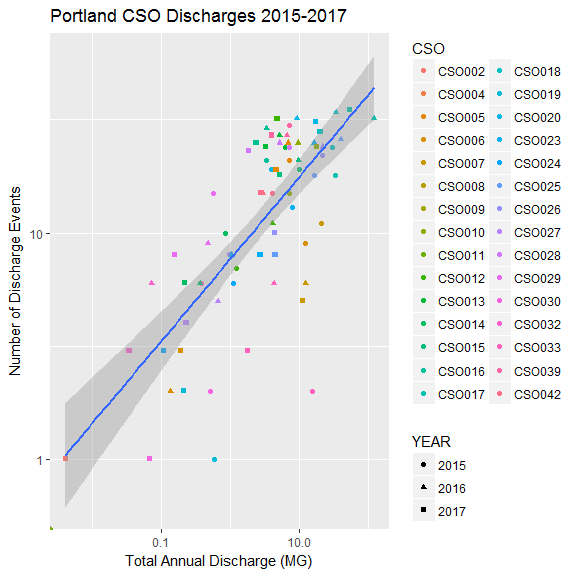

```r
plt <- ggplot(csosumsandcounts) + geom_point(aes(discharge/1000000, events, shape = YEAR , color= CSO)) + geom_smooth(aes(discharge/1000000, events), method = 'lm')
plt <- plt + xlab("Total Annual Discharge (MG)") + ylab('Number of Discharge Events') + ggtitle('Portland CSO Discharges 2015-2017')
plt <- plt + scale_x_log10() + scale_y_log10()
plt
```

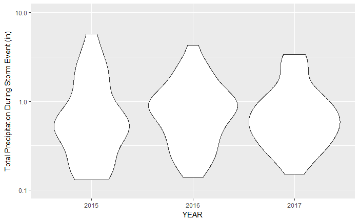

```r
plt <- ggplot(wide.data) + aes(YEAR, totprecip) + geom_violin() + ylab("Total Precipitation During Storm Event (in)") + scale_y_log10(limits =c(0.1, 10))
plt
```

## Relationship between total and maximum rainfall

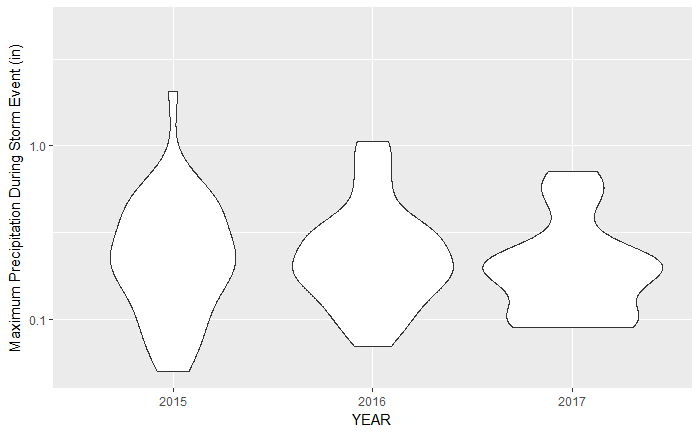

```r
plt <- ggplot(wide.data) + aes(YEAR, maxprecip) + geom_violin() + ylab("Maximum Precipitation During Storm Event (in)") + scale_y_log10(limits =c(0.05, 5))
plt
```

# Relationship between Discharges and Rainfall

## Number of Discharging Outfalls

```r
tmp <- wide.data %>% select(startdate, totprecip, maxprecip, TOTAL, YEAR) %>% mutate(Month = factor(format(startdate, "%m"),
           labels = c("jan", "feb", "mar", "apr", "may", "jun", "jul", "aug", "sep", "oct", "nov", "dec")))
summary(tmp)
```

```
   startdate            totprecip        maxprecip         TOTAL            YEAR        Month
 Min.   :2015-01-18   Min.   :0.1300   Min.   :0.050   Min.   :    2000   2015:35   jun    :14
 1st Qu.:2015-10-06   1st Qu.:0.3675   1st Qu.:0.130   1st Qu.:  410750   2016:38   may    :13
 Median :2016-08-14   Median :0.6250   Median :0.210   Median : 1585150   2017:39   jul    :11
 Mean   :2016-07-27   Mean   :0.9523   Mean   :0.279   Mean   : 6289487             aug    :10
 3rd Qu.:2017-05-02   3rd Qu.:1.1275   3rd Qu.:0.320   3rd Qu.: 6041500             sep    :10
 Max.   :2017-12-12   Max.   :5.7300   Max.   :2.050   Max.   :76692000             nov    :10
                                                                                    (Other):44
```

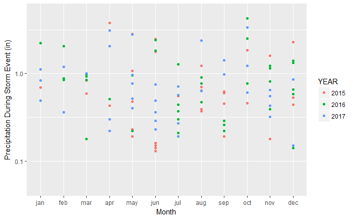

```r
plt <- ggplot(tmp) + aes(Month, totprecip, color = YEAR) + geom_point() +
  ylab("Precipitation During Storm Event (in)") + scale_y_log10(limits =c(0.05, 5))
plt
```

```r
rm(tmp)
```

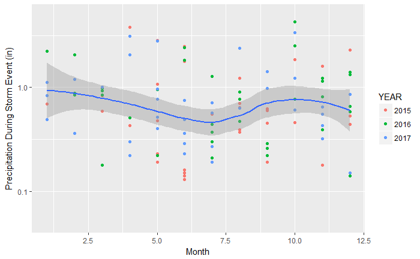

```r
tmp <- wide.data %>% select(startdate, totprecip, maxprecip, TOTAL, YEAR) %>% mutate(Month =as.integer(format(startdate, "%m")))
plt <- ggplot(tmp)  + geom_point(aes(Month, totprecip, color = YEAR)) +  geom_smooth(aes(Month, totprecip)) +
  ylab("Precipitation During Storm Event (in)") + scale_y_log10(limits =c(0.05, 5))
plt
```

```r
rm(tmp)
```

## Discharge VOlumes by Rainfall

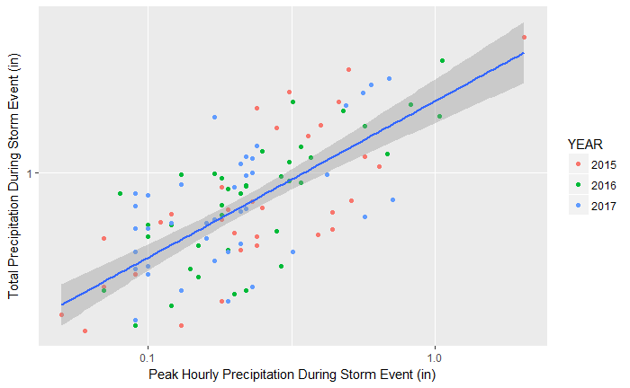

```r
plt <- ggplot(wide.data) + geom_point(aes(maxprecip, totprecip, color = YEAR)) + geom_smooth(aes(maxprecip, totprecip), method = 'lm')
plt <- plt + ylab("Total Precipitation During Storm Event (in)") + xlab("Peak Hourly Precipitation During Storm Event (in)")
plt <- plt + scale_y_log10() + scale_x_log10()
plt
```

There is some weak indication of lower discharges during low rain events.

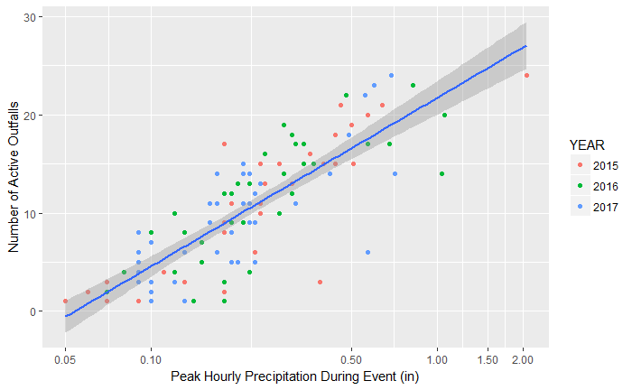

```r
plt <- ggplot(wide.data)
plt <- plt + geom_point(aes(maxprecip, COUNT, color = YEAR)) + geom_smooth(aes(maxprecip, COUNT), method = "lm")
plt <- plt + scale_x_log10(breaks = c(0.01, 0.05, 0.1, 0.5, 1, 1.5, 2))
plt <- plt + ylab('Number of Active Outfalls') + xlab('Peak Hourly Precipitation During Event (in)')
plt
```

So, visually, it looks like the NUMBER of CSOs discharging is determined mostly by peak discharge, but the VOLUME of discharge is more strongly influenced by TOTAL discharge. That probably makes a lot of sense.

Can we symbolize a 3-D surface and see what it looks like?

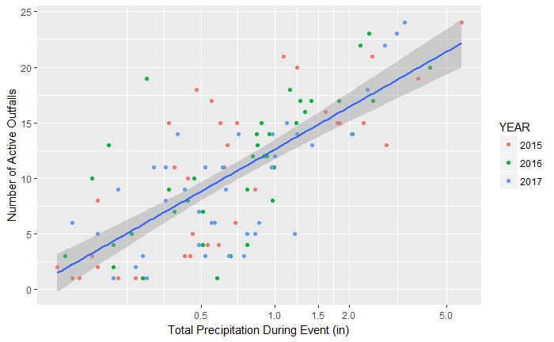

```r
plt <- ggplot(wide.data)
plt <- plt + geom_point(aes(totprecip, COUNT, color = YEAR)) + geom_smooth(aes(totprecip, COUNT), method = "lm")
plt <- plt + scale_x_log10(breaks = c(0.01, 0.05, 0.1, 0.5, 1, 1.5, 2,5,10))
plt <- plt + ylab('Number of Active Outfalls') + xlab('Total Precipitation During Event (in)')
plt
```